# R Beginners Course

Exercise 2

## Welcome

Welcome to the second tutorial of the R Beginners Course of Spatial analysis. We hope that you are ready to try some things out!

## Outline

This tutorial is composed by three exercises:

- Pre-processing a MOD16 Ea
- Aggregate SSEBop
- Time Series Analysis

After the completion of this tutorial you will be able to pre-process gridded data, aggregate gridded data to multiple temporal resolutions, and work with time series in R.

## Pre-processing a MOD16 Ea

The MOD16A2 dataset (Mu et al. 2007; Mu, Zhao, and Running 2011) is an 8-day composite product with a spatial resolution of 500 m. The algorithm is based on the Penman-Monteith equation and uses daily meteorological reanalysis data (air pressure, air temperature, humidity and radiation) in combination with remotely sensed products obtained from MODIS such as albedo, land cover, and vegetation property dynamics. This dataset provides actual evaporation (Ea) and potential evaporation (PET), which represent the summation of 8-day total water loss through ET (0.1 kg m −2 8-day −1 ), while their associated latent heat fluxes (LE and PLE, respectively) are the average total energy over a unit area per day (over the designated 8-day period) (Running et al. 2017).

Table 1: Detailed information of the MOD16A2 product.

| Datasets | Meaning | Units | Data type | Valid range | Scale factor |
| --- | --- | --- | --- | --- | --- |
| ET_500m | 8-day total ET | kg m$^{-2}$ 8d$^{-1}$ | int16 | -32767 $\sim$ 32767 | 0.1 |
| LE_500m | 8-day average LE | J m$^{-2}$ d$^{-1}$ | int16 | -32767 $\sim$ 32767 | 10000 |
| PET_500m | 8-day total PET | kg m$^{-2}$ 8d$^{-1}$ | int16 | -32767 $\sim$ 32767 | 0.1 |
| PLE_500m | 8-day average PLE | J m$^{-2}$ d$^{-1}$ | int16 | -32767 $\sim$ 32767 | 10000 |
| ET_QC_500m | Quality control | - | unit8 | 0 $\sim$ 254 | - |

In addition, there are 7 fill values for non-vegetated grid-cells, where ET is not calculated (Running et al. 2017). These values are:

1. Out of the Earth = 32767
2. Water bodies = 32766
3. Barren or sparsely vegetated areas = 32765
4. Permanent snow and ice = 32764
5. Permanent wetlands = 32763
6. Urban or built-upareas = 32762
7. Unclassified 32761

### Objective of the task

The student should be able to read a raw MOD16A2 file (provided with this exercise) and process it to obtain ETa values.

1. Obtain a raster file where ETa is expressed in accumulated mm over the 8-day period and all grid-cells without a measurement are stored as NAs.
2. Export the pre-processed raster to a specific folder

## Aggregate SSEBop

The operational Simplified Surface Energy Balance (SSEBop) product (Senay et al. 2013) combines ET fractions generated from MODIS thermal imagery with reference evaporation using a thermal index approach to generate 10-day Ea estimates in milimeters. This product uses pre-defined, seasonally dynamic boundary conditions that are unique to each grid-cell for the cold/wet and hot/dry reference points. In SSEBop, eachmonth is divided into three time steps: $i)$ the first 10 days; $ii)$ the second 10 days; and $iii)$ the remaining days from the 21st to the end of the month.

### Objective of the task

The student should process the 10-day SSEBop to obtain monthly Ea values cropped to the extent of Rwanda for 2009–2011. The derived monthly rasters must be saved in a new folder (with information about the year and month in the file name). For this exercise, 10-day SSEBop raster files are provided (from 2008–2013). Figure 1 shows the first 16 raster files of the 10-day SSEBop data, while Figure 2 plots the shapefile where Rwanda must be subsetted.

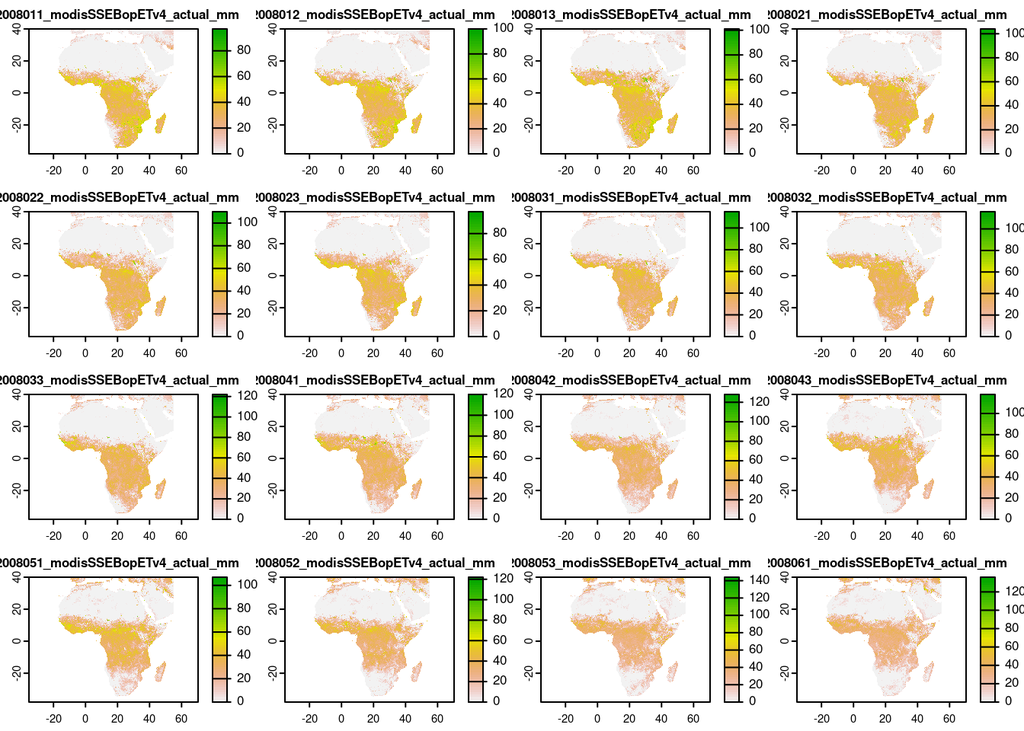

Figure 1: First 16 SSEBop raster files provided

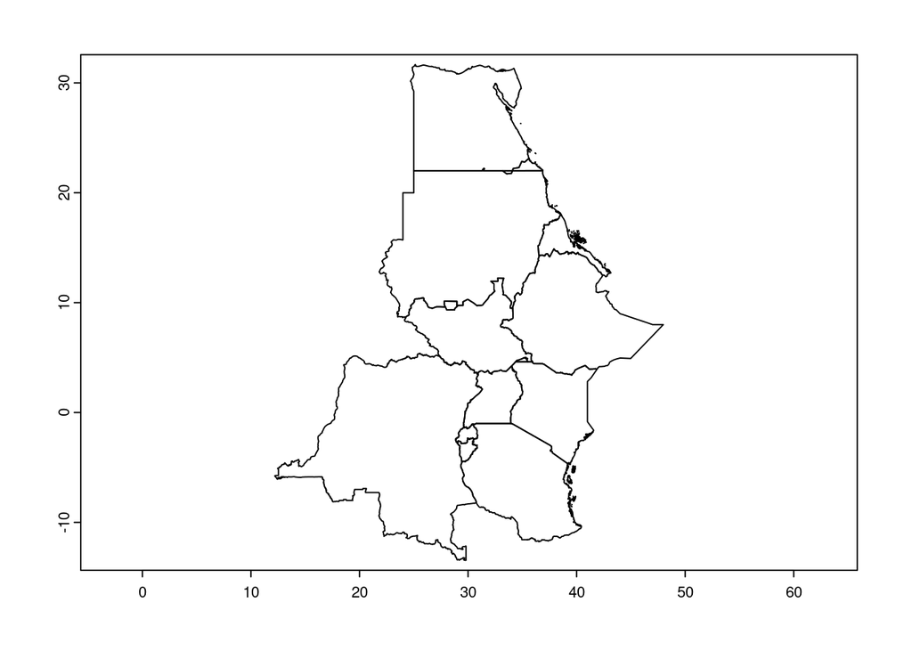

Figure 2: Shapefile of the Nile Basin countries